# TASK 3: Santa Barbara urchins

Jaxon Stuhr

10/25/2021

## Task Overview

This code wrangles and analyzes data on Santa Barbara urchins. Two species, red urchins and purple urchins, are compared at 5 sites around Santa Barbara, CA, on the basis of observed size and prevalence.

**Data citation:**

Reed, D. 2020. SBC LTER: Reef: Long-term experiment: Kelp removal: Urchin size frequency distribution ver 20. Environmental Data Initiative. https://doi.org/10.6073/pasta/5a1e9ef03aa47bd2225c0bb98a02a63b.

```r
knitr::opts_chunk$set(echo = TRUE, message = FALSE, warning = FALSE)
library(tidyverse)
library(janitor)
library(here)
library(kableExtra)
library(lubridate)
```

```r
# read in urchins data
urchins = read.csv(here("data", "urchins.csv"))
```

## Section 1: Size comparisons, purple and red urchins

### Data Visualization

A comparison of the size distribution for purple and red urchins.

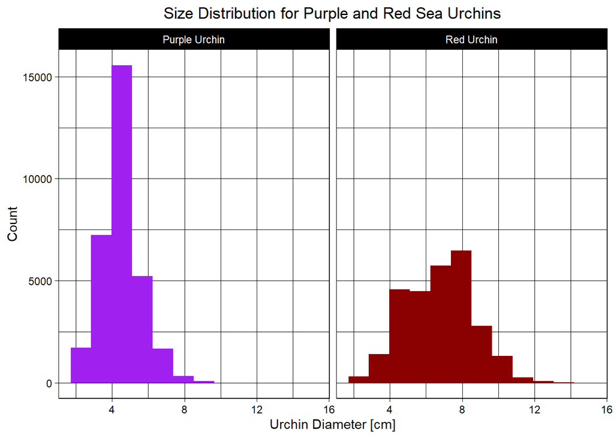

```r
# plot using urchins data, x var = size
ggplot(data = urchins, aes(x = SIZE, fill = COMMON_NAME)) +
  # histogram w 12 bins
  geom_histogram(bins = 12) +
  # facet wrap based on common name
  facet_wrap(~ COMMON_NAME) +
  # manually control colors
  scale_fill_manual(values=c("Purple", "Dark Red")) +
  # add x, y labels and title
  labs(x = "Urchin Diameter [cm]",
       y = "Count",
       title = "Size Distribution for Purple and Red Sea Urchins") +
  # change theme
  theme_linedraw() +
  # center title
  theme(plot.title = element_text(hjust = 0.5)) +
  # remove legend
  guides(fill = FALSE)
```

Fig 1: Urchin diameter distribution [cm] for red and purple urchins in Santa Barbara, CA

### Descriptive statistics table

Building a summary table including the mean, median, standard deviation, and sample size and sorting by species (red or purple urchin).

```r
urchin_stats = urchins %>%
  # group by common name of urchins (red or purple)
  group_by(COMMON_NAME) %>%
  summarize(
    # add summary stats mean, median, sd, sample size
    mean_size = round(mean(SIZE),1),
    median_size = median(SIZE),
    sd_size = round(sd(SIZE),1),
    sample_size = n()
  )

urchin_stats %>%
  # build table w kbl extra, rename columns
  kbl(caption = "Table 1: Santa Barbara Urchins Summary Statistics", col.names = c("Common Name", "Mean Diameter [cm]", "Median Diameter [cm]", "Standard Deviation [cm]", "Sample Size")) %>%
  kable_classic(full_width = F, html_font = "Cambria")
```

Table 1: Santa Barbara Urchins Summary Statistics

| Common Name | Mean Diameter [cm] | Median Diameter [cm] | Standard Deviation [cm] | Sample Size |
| --- | --- | --- | --- | --- |
| Purple Urchin | 4.5 | 4.5 | 1.2 | 31805 |
| Red Urchin | 6.8 | 7.0 | 1.9 | 27408 |

### Section 1 Analysis

```r
# calculate difference
mean_size_dif = (urchin_stats$mean_size[2] - urchin_stats$mean_size[1])
# calculate percent difference between sample means
mean_size_percent_dif =
  round(
    200 *
      (urchin_stats$mean_size[2] - urchin_stats$mean_size[1]) /
      (urchin_stats$mean_size[2] + urchin_stats$mean_size[1]),
    1)
#min and max red urchin size
reds = urchins %>%
  filter(COMMON_NAME == "Red Urchin")
min_red = min(reds$SIZE)
max_red = max(reds$SIZE)
#min and max purple urchin size
purples = urchins %>%
  filter(COMMON_NAME == "Purple Urchin")
min_purple = min(purples$SIZE)
max_purple = max(purples$SIZE)
```

The red urchins were, on average 2.3 cm larger and 40.7 % larger in diameter than the purple urchins. The red urchins also had a much larger spread, with diameters ranging from 2.5 to 15 cm, whereas the purple urchins diamters ranged from 2.5 to 9 cm.

## Section 2: Exploring purple urchin counts by site and year

### Pre-processing the purple urchins data

```r
# start w urchins
purple_urchins = urchins %>%
  # only purple ones
  filter(COMMON_NAME == "Purple Urchin") %>%
  # use libridate on DATE
  mutate(DATE = mdy(DATE)) %>%
  # add yr column
  mutate(YEAR = year(DATE)) %>%
  # add column w full site names
  mutate(site_full = case_when(
    SITE == "NAPL" ~ "Naples Reef",
    SITE == "AQUE" ~ "Arroyo Quemado Reef",
    SITE == "CARP" ~ "Carpinteria Reef",
    SITE == "MOHK" ~ "Mohawk Reef",
    SITE == "IVEE" ~ "Isla Vista Reef"
  ))
```

### Plotting counts of purple urchins recorded at each site by year

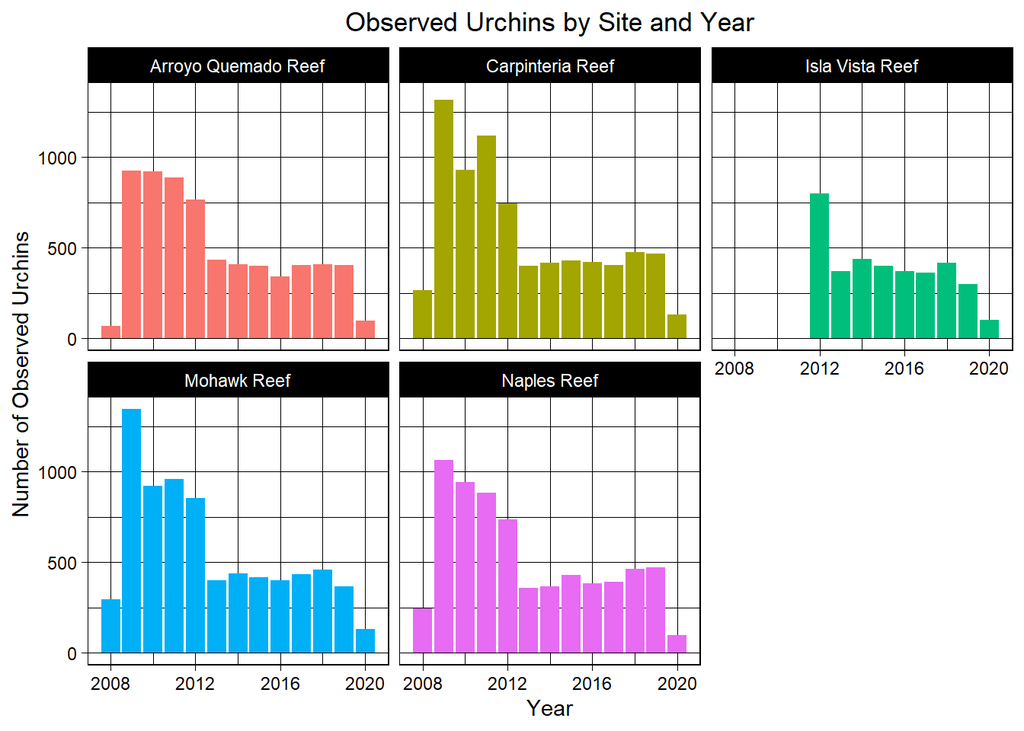

```r
# plot w x =  yr, y = count
ggplot(purple_urchins_by_site_year, aes(x = YEAR, y = n, fill = site_full)) +
  # column graph
  geom_col() +
  # break up by site
  facet_wrap(~ site_full) +
  # add labels
  labs(x = "Year", y = "Number of Observed Urchins", title = "Observed Urchins by Site and Year") +
  # change theme
  theme_linedraw() +
  # center title
  theme(plot.title = element_text(hjust = 0.5)) +
  # remove legend
  guides(fill = FALSE)
```

Fig 2: Observed Urchin counts for purple urchins at 5 sites around Santa Barbara, CA for years 2008 - 2020